# lab1

```python
import numpy as np
```

Create an array that starts from 1, ends at 20, and is incremented by 3:

```python
array1 = np.arange(1, 21, 3)
print(array1)
```

```
[ 1  4  7 10 13 16 19]
```

Create a new array of shape 3 with random numbers between 0 and 1:

```python
array2 = np.random.rand(3)
print(array2)
```

```
[0.32679543 0.35788991 0.22762311]
```

Create a 2D array and perform slicing operations:

```python
import numpy as np

# Creating a 2D array
array_2d = np.array([[10, 20, 45],
                     [30, 12, 16],
                     [42, 17, 56]])

# Slicing the first two rows
first_two_rows = array_2d[:2, :]

# Slicing the last two rows
last_two_rows = array_2d[1:, :]

# Printing the results
print("First two rows:")
print(first_two_rows)
print()

print("Last two rows:")
print(last_two_rows)
```

```
First two rows:
[[10 20 45]
 [30 12 16]]

Last two rows:
[[30 12 16]
 [42 17 56]]
```

Create two 2x2 arrays and demonstrate how you can stack the elements vertically, horizontally, and split the arrays into smaller arrays.

```python
import numpy as np

# Creating two 2x2 arrays
array1 = np.array([[1, 2],
                   [3, 4]])

array2 = np.array([[5, 6],
                   [7, 8]])

# Vertically stacking the arrays
vertical_stack = np.vstack((array1, array2))

# Horizontally stacking the arrays
horizontal_stack = np.hstack((array1, array2))

# Splitting the horizontally stacked array
split_horizontal = np.hsplit(horizontal_stack, 2)

# Printing the original arrays
print("Original Array 1:")
print(array1)
print()

print("Original Array 2:")
print(array2)
print()

# Printing the vertically stacked array
print("Vertically Stacked Array:")
print(vertical_stack)
print()

# Printing the horizontally stacked array
print("Horizontally Stacked Array:")
print(horizontal_stack)
print()

# Printing the split arrays
print("Split Horizontal Array 1:")
print(split_horizontal[0])
print()

print("Split Horizontal Array 2:")
print(split_horizontal[1])
```

```
Original Array 1:
[[1 2]
 [3 4]]

Original Array 2:
[[5 6]
 [7 8]]

Vertically Stacked Array:
[[1 2]
 [3 4]
 [5 6]
 [7 8]]

Horizontally Stacked Array:
[[1 2 5 6]
 [3 4 7 8]]

Split Horizontal Array 1:
[[1 2]
 [3 4]]

Split Horizontal Array 2:
[[5 6]
 [7 8]]
```

Create two matrices X= ([[5, 7, 2], [4, 5, 6], [7, 4 ,2]]) Y= ([[4, 2], [6, 2], [4, 2]]), Is it possible to multiply these matrices?

```
      Demonstrate the case when it is not possible to.
```

```python
import numpy as np

# Creating matrices X and Y
X = np.array([[5, 7, 2],
              [4, 5, 6],
              [7, 4, 2]])

Y = np.array([[4, 2],
              [6, 2],
              [4, 2]])

# Checking if matrix multiplication is possible
if X.shape[1] == Y.shape[0]:
    result = np.dot(X, Y)
    print("Matrix multiplication is possible.")
    print("Result of matrix multiplication:")
    print(result)
else:
    print("Matrix multiplication is not possible.")
```

```
Matrix multiplication is possible.
Result of matrix multiplication:
[[70 28]
 [70 30]
 [60 26]]
```

Reason behind matrix multiplication is not possible:

If the number of columns in X does not match the number of rows in Y, matrix multiplication is not possible, and an appropriate message will be displayed.

Create two arrays, x = ([2, -1, -8]) y = ([3, 1, -2]), Find the Shape, Number of dimensions of vector x.

```
      Reshape the vector x to a matrix of size (3,1) and determine the number of dimensions after reshaping y to a matrix of (3,1).
```

```python
import numpy as np

# Creating arrays x and y
x = np.array([2, -1, -8])
y = np.array([3, 1, -2])

# Finding shape and number of dimensions of vector x
x_shape = x.shape
x_dims = x.ndim

# Reshaping x and y to matrices of size (3,1)
x_matrix = x.reshape(3, 1)
y_matrix = y.reshape(3, 1)

# Determining number of dimensions after reshaping
x_matrix_dims = x_matrix.ndim
y_matrix_dims = y_matrix.ndim

# Printing the results
print("Vector x:")
print("Shape:", x_shape)
print("Number of dimensions:", x_dims)
print()

print("Reshaped matrix of x:")
print(x_matrix)
print("Number of dimensions after reshaping:", x_matrix_dims)
print()

print("Reshaped matrix of y:")
print(y_matrix)
print("Number of dimensions after reshaping:", y_matrix_dims)
print("Dimensions:", matrix2.shape)
```

[output not shown]

How does broadcasting work? Demonstrate the subtraction, multiplication by considering a 3 x 3 matrix.

The following are NumPy's broadcasting rules:

The smaller array is padded with ones on its left side until the number of dimensions match if the arrays have differing numbers of dimensions.

The array with shape equal to 1 in that dimension is extended to match the shape of the other array if the shapes of the arrays do not match in any dimension.

A "ValueError: Operands could not be broadcast together" error is raised if the arrays' matching dimensions' widths are not identical, nor is 1.

```python
import numpy as np

# Creating a 3x3 matrix
matrix = np.array([[1, 2, 3],
                   [4, 5, 6],
                   [7, 8, 9]])

# Broadcasting subtraction
subtracted = matrix - 2

# Broadcasting multiplication
multiplied = matrix * 3

# Printing the original matrix and the results
print("Original matrix:")
print(matrix)
print()

print("Matrix after subtraction:")
print(subtracted)
print()

print("Matrix after multiplication:")
print(multiplied)
```

```
Original matrix:
[[1 2 3]
 [4 5 6]
 [7 8 9]]

Matrix after subtraction:
[[-1  0  1]
 [ 2  3  4]
 [ 5  6  7]]

Matrix after multiplication:
[[ 3  6  9]
 [12 15 18]
 [21 24 27]]
```

Line Graph: A line graph represents data with continuous variables, where data points are connected by lines to show trends or patterns.

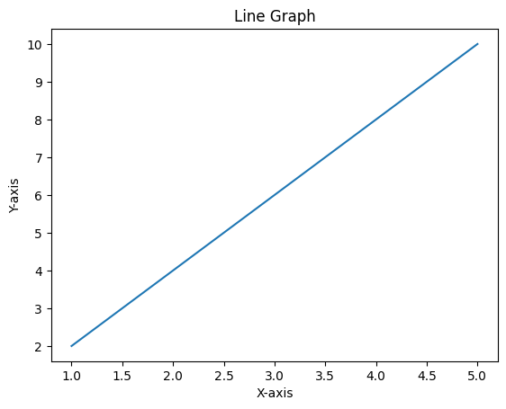

```python
import matplotlib.pyplot as plt

# Sample data
x = [1, 2, 3, 4, 5]
y = [2, 4, 6, 8, 10]

# Create the line graph
plt.plot(x, y)

# Customize the graph
plt.title("Line Graph")
plt.xlabel("X-axis")
plt.ylabel("Y-axis")

# Display the graph
plt.show()
```

Bar Graph: A bar graph displays data using rectangular bars of varying heights. Each bar represents a category, and the height of the bar indicates the value of the category.

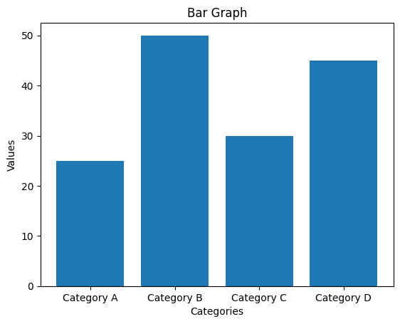

```python
import matplotlib.pyplot as plt

# Sample data
categories = ['Category A', 'Category B', 'Category C', 'Category D']
values = [25, 50, 30, 45]

# Create the bar graph
plt.bar(categories, values)

# Customize the graph
plt.title("Bar Graph")
plt.xlabel("Categories")
plt.ylabel("Values")

# Display the graph
plt.show()
```

Box Plot: A box plot, also known as a box-and-whisker plot, is a graphical representation of the distribution of a dataset. It provides a summary of the data's central tendency, spread, and outliers.

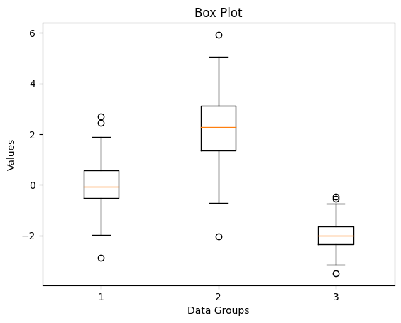

```python
import matplotlib.pyplot as plt
import numpy as np

# Sample data
data1 = np.random.normal(loc=0, scale=1, size=100)
data2 = np.random.normal(loc=2, scale=1.5, size=100)
data3 = np.random.normal(loc=-2, scale=0.5, size=100)

# Combine the data into a list
data = [data1, data2, data3]

# Create the box plot
plt.boxplot(data)

# Customize the graph
plt.title("Box Plot")
plt.xlabel("Data Groups")
plt.ylabel("Values")

# Display the graph
plt.show()
```

Scatter Plot: A scatter plot shows the relationship between two variables by plotting individual data points on a graph. Each point represents the values of the two variables.

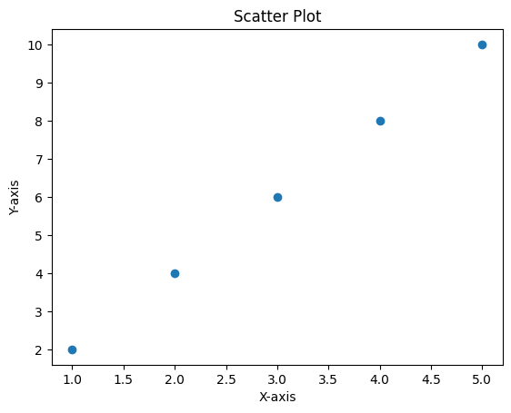

```python
import matplotlib.pyplot as plt

# Sample data
x = [1, 2, 3, 4, 5]
y = [2, 4, 6, 8, 10]

# Create the scatter plot
plt.scatter(x, y)

# Customize the graph
plt.title("Scatter Plot")
plt.xlabel("X-axis")
plt.ylabel("Y-axis")

# Display the graph
plt.show()
```

Histogram:A histogram is a graphical representation of the distribution of a dataset. It provides a visual summary of the underlying frequency or count of values within different intervals or bins. Histograms are commonly used to analyze the shape, central tendency, and spread of continuous or discrete data.

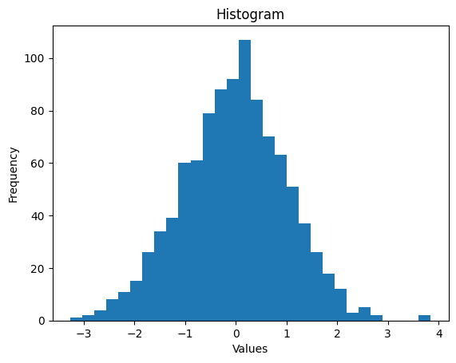

```python
import matplotlib.pyplot as plt
import numpy as np

# Sample data
data = np.random.normal(loc=0, scale=1, size=1000)

# Create the histogram
plt.hist(data, bins=30)

# Customize the graph
plt.title("Histogram")
plt.xlabel("Values")
plt.ylabel("Frequency")

# Display the graph
plt.show()
```

Part B: Solve the following two system of linear equations using matrices ( find the value of x1 and x2) and determine the number of solution using the function. Defining the feature matrix for the given set of solutions 2x+3x2-4x3 +6;x1-4x2+4x3=8

```python
import numpy as np

# Coefficient matrix A
A = np.array([[2, 3, -4],
              [1, -4, 4]])

# Constant matrix B
B = np.array([[6],
              [8]])
```

[output not shown]

So from this it is concluded that there should be one more equation for this.

```python
import numpy as np

# Coefficient matrix A
A = np.array([[3, -4, 5],
              [-1, 2, -4]])

# Constant matrix B
B = np.array([[10],
              [0]])
```

[output not shown]

It is not possible because one more equation is required for this.